# Mietspiegel

### Alter +

Die folgenden beiden Grafiken geben den Nettomietpreis fuer die unterschiedlichen Altersklassen in Abhaengigkeit von der Zimmeranzahl (a) und Gehobene Kueche (b) wieder. Fuer die Zimmeranzahl koennen wir einen deutlichen unterschied zwischen sechs Zimmer Wohnungen bei bis zu 20 Jahre alten Wohnungen und anderen sechs Zimmer Wohnungen. Bei Wohnungen mit gehobener Kueche faellt auf, dass im Vergleich zu Wohnungen ohne gehobener Kueche der Nettomietpreis ueber die Alterskategorieen konstant verlaeuft. Hier wirkt sich also das Alter weniger stark auf den Mietpreis aus.

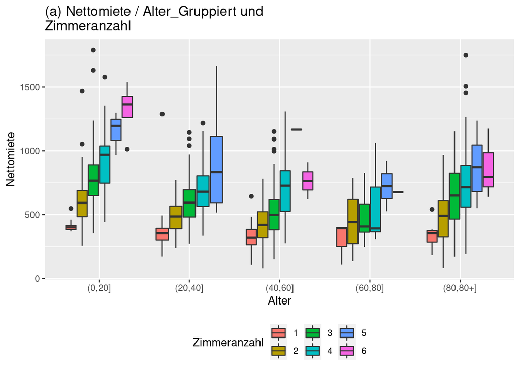

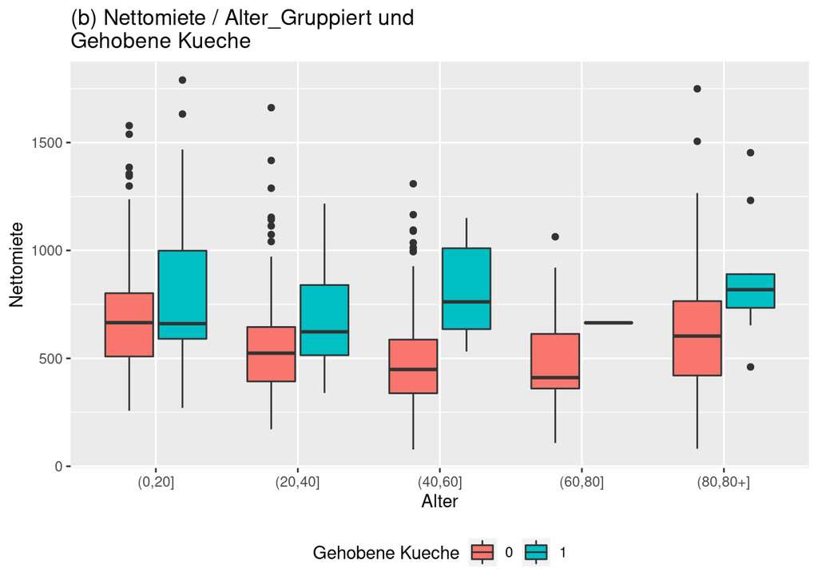

### Wohnanlage

Die folgende Grafik gibt die Nettomiete je Wohnanlage und Extra Badausstattung wieder. Wie koennen erkennen, dass vor allem in der besten Wohnanlage ein deutlich hoeherer Mietepreis fuer Wohnungen mit Extra Badausstattung vorhanden ist wie fuer andere.

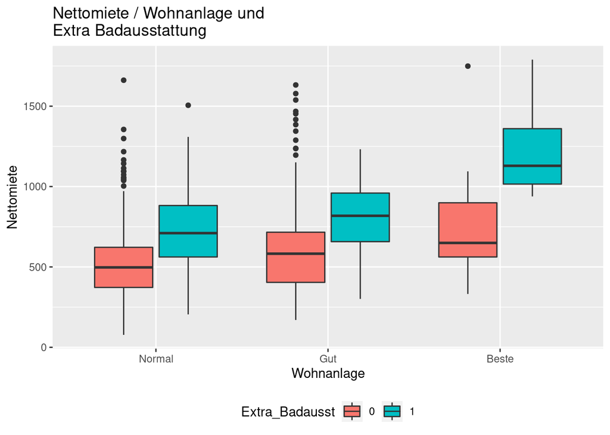

# Modellselektion

Bevor das eigentliche Modell geschaetzt wird, soll ein Entscheidungsbaum uns weitere Auskuenfte ueber moegliche Zusammenhaenge geben.

## Entscheidungsbaum

Entscheidungsbaeume sind ein flexibeles Mittel, um klassenspezifische Durchschnitte zu berechnen. Entscheidungsbaeume koennen aber zur Variablenselektion verwendet werden, da sie eine Hierarchie der wichtigsten Variablen erzeugen. Folgende Grafik gibt den Entscheidungsbaum fuer diesen Datensatz wieder.

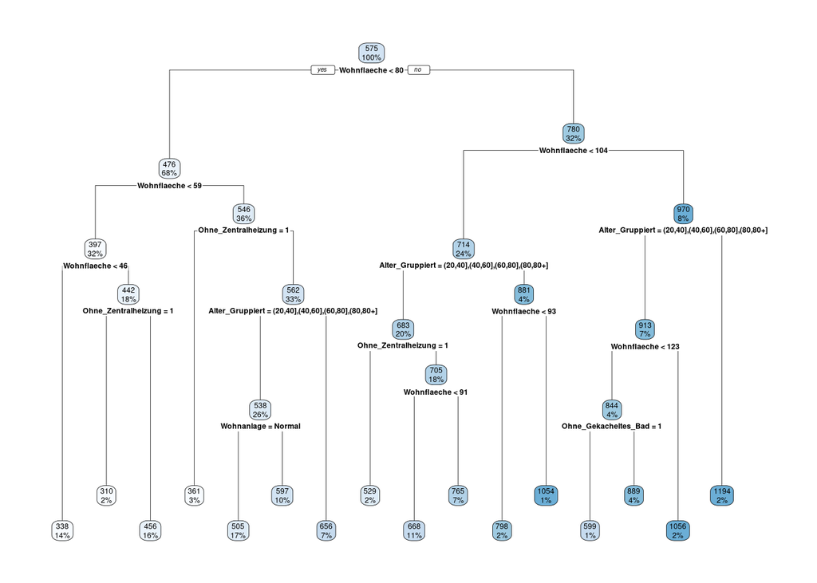

Die Grafik ist wie folgt zu verstehen: Auf oberster Ebene wird der Mittelwert der Nettomiete 575 wiedergegeben. Dieser Enthaelt alle, d.h. 100% der Beobachtungen. Die groesste Varianzreduktion kann duch eine Aufteilung der Wohnflaeche in Wohnungen die kleiner oder groesser wie 80 Quadratmeter (qm) sind erreicht werden. Der durchschnittliche Nettomietpreis fuer Wohnungen die kleiner wie 80 qm sind ist 476 und fuer Wohnungen die groesser wie 80 qm sind 780. Weitere Unterteilungen folgen diesem Muster.

Wohnflaeche ist auf den ersten beiden Ebenen die Entscheidungsvariable. Fuer Wohnungen unter 80 qm koennen wir beobachten, dass im Folgenden die Variablen “Ohne Zentralheizung” und das gruppierte Alter zu weiteren Entscheidungsvariablen werden. Fuer Wohnungen groesser gleich 80 qm folgt in dritter Ebene das gruppierte Alter als Entscheidungsvariable, wobei in Folgenden Ebenen Wohnflaeche wieder als Entscheidungsvariable Auftaucht.

Zusammenfassend halten wir fest, dass die Wohnflaeche die dominanteste Variable in der Erklaerung des Nettomietpreises ist. Fuer kleiner Wohnungen ist dann die Variable Ohne_Zentralheizung als zweitdominanteste Variable. Fuer groesser Wohnungen sind ebenfalls die Wohnflaeche und das Alter die dominanten Faktoren die den Nettomietpreis erklaeren.

## Variablenselektion und Modifikation

Die hohe Korrelation zwischen Wohnflaeche und Zimmeranzahl (0.8) fuehrt zu einem Schaetzproblem wenn beide Variablen zur Modellierung verwendet werden. Konkret fuehrt eine Inklusion beider Variablen zu einem positiven Zusammenhang zwischen Wohnflaeche und Nettomietpreis einen negativen Zusammenhang zwischen Zimmeranzahl und Nettomietpreis. Da wir bereits einen stark positiven Zusammenhang zwischen Zimmeranzahl und Nettomietpreis beobachten konnten macht ein negativer Zusammenhang inhaltlich keinen Sinn. Aufgrund der besseren Interpretierbarkeit, sowie numerischer Eigenschaften, der Wohnflaeche wird diese stellvertretend fuer beide Variablen fuer die Schaetzung verwendet. Ein weiterer Grund liegt in der Eindeutigkeit der Wohnflaeche. Eine kleine Wohnung kann auch mehrere Zimmer haben und eine grosse Wohnung kann nur wenige Zimmer haben und ist somit nicht unbedingt eindeutig.

## Methode

Geschaetzt wird ein multivariates lineares Regressionsmodell. Die Modellselektion erfolgt in einem Dreischrittverfahren. Im ersten Schritt wird aufgrund der geringen Anzahl an Beobachtungen und Variablen die Best Subset Methode zu Modellschaetzung verwendet. Im zweiten Schritt werden wir das Modell aus der Best Subset Methode um die gemachten Interaktionen ergaenzen. Wenn notwendig wird dann das Modell mit Interaktionen dann noch “manuell” verfeinert.

### Best Subset

Das Best Subset Verfahren schaetzt jedes moegliche Modell aus den vorhandenen Variablen ohne Interaktionen oder Transformationen und selektiert aus allen das beste. Konkret werden zuerst alle Modelle mit einer erklaerenden Variablen, dann alle mit zwei usw, bis letztendlich das Modell mit allen erklaerenden Variablen gerechnet wird. In jeder Stufe wird das beste Modell bestimmt. Zuletzt wird dann aus den besten Modellen nochmals das Beste selektiert.

Das beste Modell ist jenes mit allen 8 erklaerenden Variablen. Fuer dieses Modell erhalten wir einen angepassten $R^2$ Wert von 0.62.

### Interaktionen

Da Zimmeranzahl aus der weiteren Analyse bereits ausgeschlossen wurde, bleiben aus der Trivariaten Analyse folgende Interaktionseffekte uebrig:

- Wohnflaeche: Alter_Gruppiert-, Wohnlage-, Ohne Zentralheizung und Gehobene Kueche
- Alter: Gehobene Kueche
- Wohnanlage und Extra Badausstattung

Das Modell hat einen adjustierten $R^2$ von 0.64.

## Interpretation

Eine Wohnung hat einen Grundpreis von 168. Mit jedem Quadratmeter Wohnflaeche steigt der Mietpreis um 7. Eine Wohnung die zwischen 20 und 40 Jahren alt ist, hat einen um 89 geringeren Mietpreis wie eine, die bis 20 Jahre alt ist. Die Interpretation fuer die weiteren Variablen folgt analog.

# Modell Analyse

## Homogene Varianzen

Schaetzt man ein lineares Modell mit ungleichen Varianzen in den Fehlertermen, dann ist zwar der Schaetzer im noch erwartungstreu, aber es gibt einen anderen mit geringerer Varianz. Somit testen wir im folgenden, ob in diesem Modell die Fehler ungleiche Varianzen aufweisen. Wenn ja, werden wir das selektierte Modell mit einem gewichteten linearem Regressionsmodell vergleichen. Letzters sollte theoretisch zu einer Varianzreduzierung fuehren.

Informell kann man die Varianzhomogenitaet testen indem die Modellprognose gegen die Residuen geplottet werden. Sind die Fehler konstant um eine Gerade ohne erkennbares Muster gestreut, gehen wir von konstanten Varianzen aus. In der linken Grafik sind die Ergebnisse fuer das normale Modell in der rechten fuer das gewichtete.

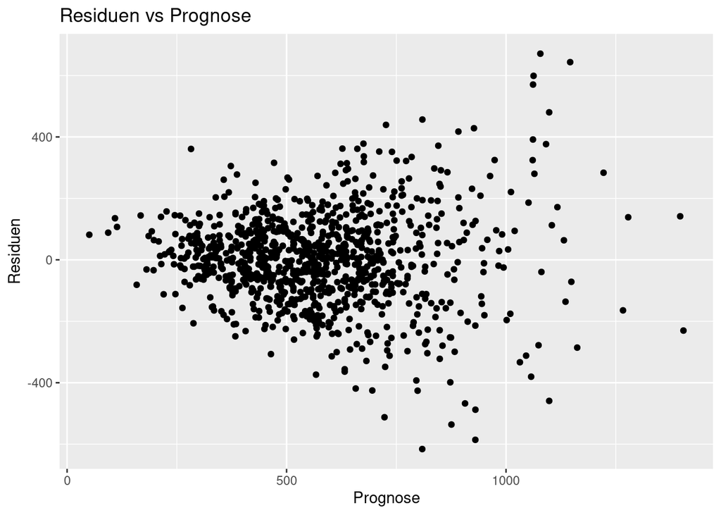

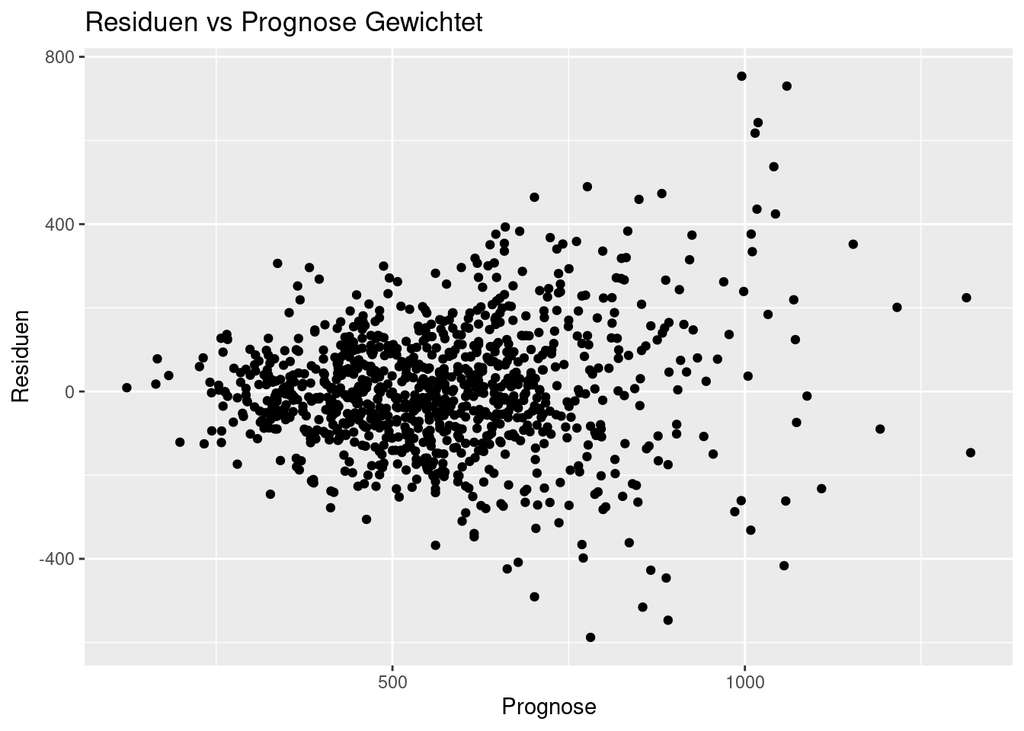

Wir erkennen keinen markanten Unterschied. Vergleichen wir die Durchschnitte der quadrierten Residuen aus dem normalen Modell 22810 und dem gewichteten 23351 erkennen wir, dass durch die Gewichtung sogar eine verschlechterung erreicht wurde. Wir bleiben somit beim urspruenglichen Modell.

## Ausreisser

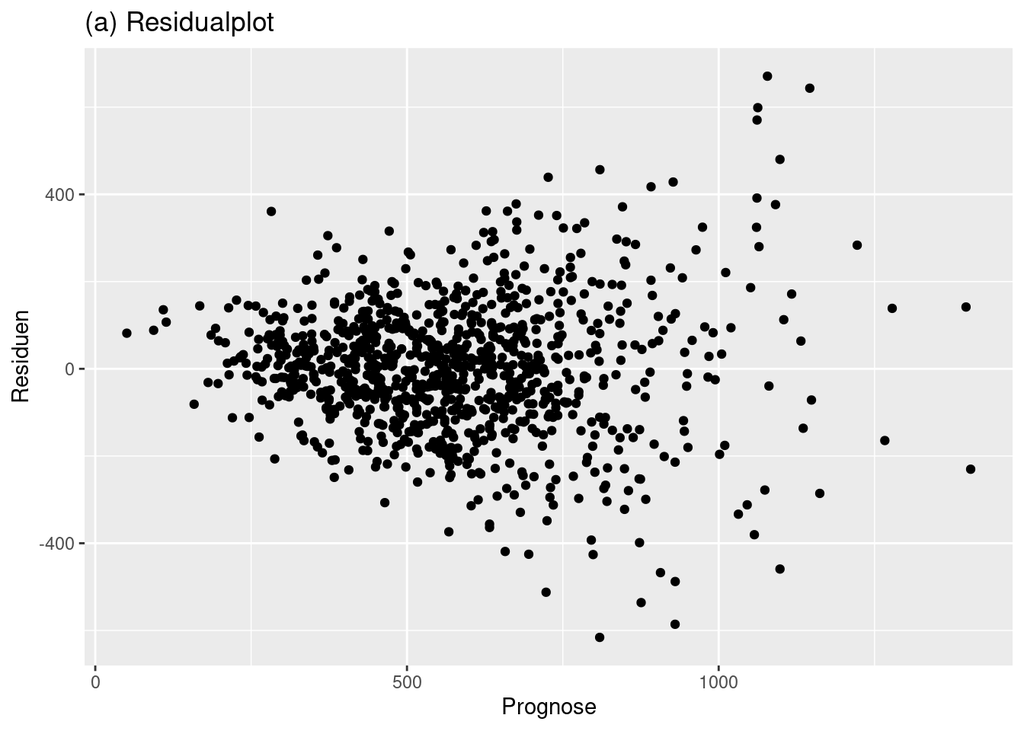

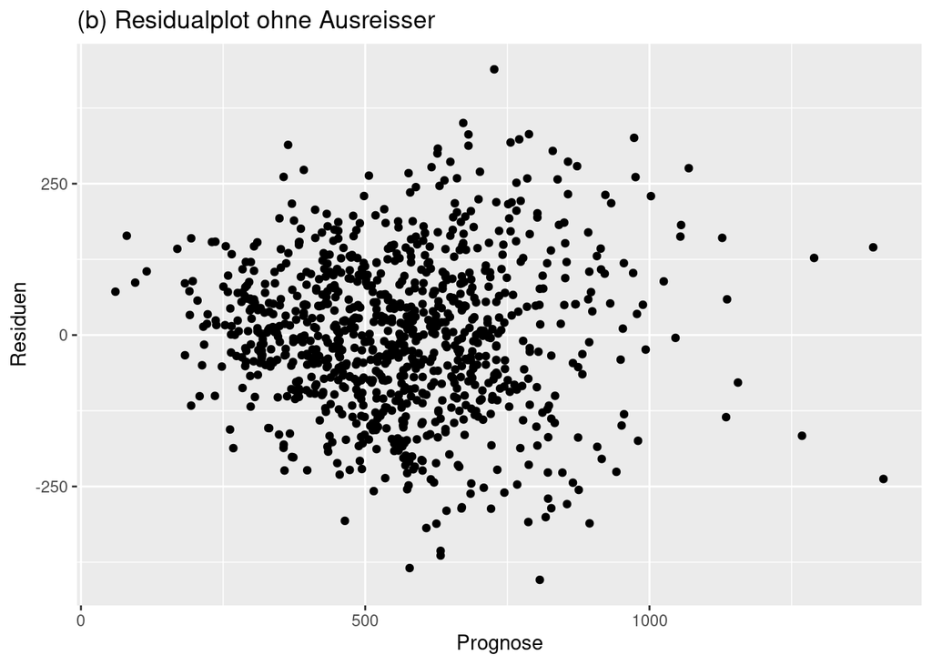

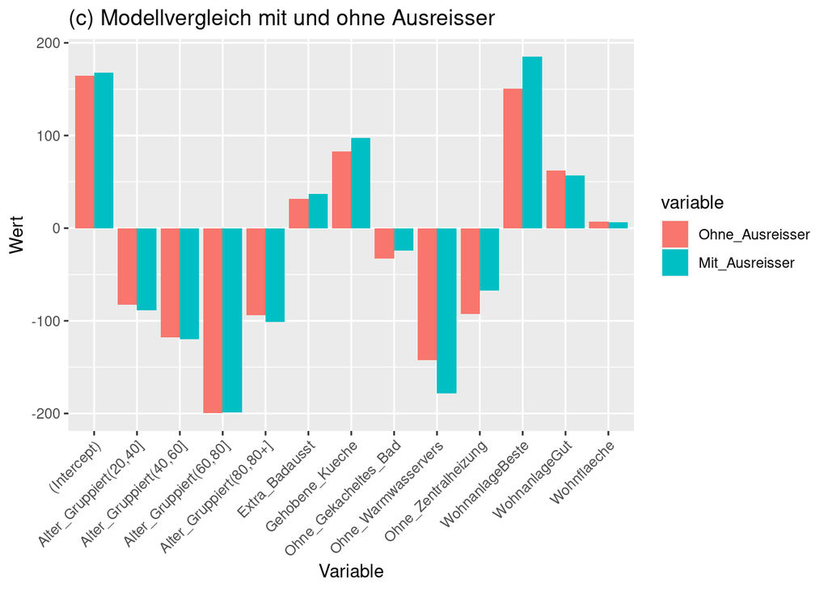

# Conclusio

Basierend auf der Datenanalyse und der Best Subset Methode wurden verschiedene lineare Modelle mit unterschiedlicher Komplexitaet geschaetzt. Ein Entscheidungsbaum hat uns zusaetzliche Informationen ueber die hierarchische Struktur der Variablen gegeben. Hieraus konnten wir deutlich entnehmen, dass Wohnflaeche die dominanteste Variable zur Erklaerung des Nettomietpreises ist.

Anhand der Best Subset Methode wurde bewertet, welches lineare Modell ohne Interaktionen oder weitere Variablentransformationen das beste ist. Aus diesem Verfahren wurde ein Modell mit allen zur Verfuegung stehenden erklaerenden Variablen gewaehlt. Dieses Modell wurde im naechsten Schritt um einige aus der Trivariaten Analyse stammenden Interaktionen ergaenzt. Dieses Modell hat einen hoeheren Erklaerungsgehalt, ist aber fuer die Anwendung unbrauchbar, da nur ganz wenige Variablen statistisch signifikant sind. Aus diesem Grund wurde noch ein Zusaetzliches Modell mit nur den aus dem vorherigem Modell statistisch signifikanten Interaktionen als Zusatz zum Best Subset Modell gerechnet. Dieses Modell ist allerdings in seiner Prognoseguete schlechter als das Best Subset Modell. Aus diesen Gruenden wurde das Best Subset Modell als finales Modell gewaehlt.

Im letzten Schritt wurde das Modell auf Verletztung der Varianzhomogenitaet sowie auf den Einfluss von Ausreissern getestet. Das Modell weist ungleiche Varianzen in den Fehlern auf. Dieses Phaenomen wirkt sich zwar nicht auf die Koeffizienten selber, sondern auf deren Varianz, aus. In Konsequenz gibt es theoretisch einen anderen Schaetzer mit geringerer Varianz. Diesen zu finden sollte durch ein gewichtetes lineares Modell erreicht werden. In diesem Modell bekommen Beobachtungen mit hoeherer Varianz eine geringere Gewichtung und tragen somit weniger zum Ergebnis bei. Allerdings fuehrt dieses Modell zu einer hoeheren Residuenvarianz womit auch dieses Verfahren verworfen wird. Nach dem Cook’s Distance Kriterium wurden Ausreisser im Modell identifiziert. Im Folgenden wurde das Best Subset Modell einmal mit und einmal ohne Ausreisser gescheatzt und die Ergebnisse miteinander verglichen. Hier kamen keine besonders auffaelligen Aenderungen im Modell zutage. Wesentlicher ist allerdings, dass es keine offensichtliche Gruende gibt, Ausreisser zu entfernen. Aus diesem Grund wurde auch hier zugunsten des Modells mit Ausreissern entschieden.

Gegen anderweitige Transformationen von Variablen wie zB Berechnung von Quadratmeterpreisen wurde aufgrund von Anwendungsgruenden entgegenentschieden. Dieses Modell, so wie es ist, kann auf jede neue Beobachtung der Form des Datensatzes direkt zur schaetzung des Nettomietpreises verwendet werden.

Basierend auf allen gemachten Analysen wird sich zugunsten eines linearen Regressionsmodell mit allen vorhandenen Variablen, exklusive der Zimmeranzahl, ohne Interaktionen zur Erklaerung des Nettomietpreises entschieden.